# Exploratory Data Analysis

Author: David Saucedo Date: Sept 30, 2022

[figure not shown]

image info

## **Company’s Description**

**FORM** is a Mexican company located at The Parque Industrial El Sabinal at Apodoca, Nuevo León. Briefly, FORM develops packaging solutions which add value to the supply chain our their clients. In so doing, FORM’s solutions not only protect its costumers’ products, but also address the costumers’ needs during the transportation and storage operations.

#### loding required libriaries

```r
library(foreign)
library(dplyr)        # data manipulation
library(forcats)      # to work with categorical variables
library(ggplot2)      # data visualization
library(janitor)      # data exploration and cleaning
library(Hmisc)        # several useful functions for data analysis
library(psych)        # functions for multivariate analysis
library(naniar)       # summaries and visualization of missing values NAs
library(dlookr)       # summaries and visualization of missing values NAs
library(corrplot)     # correlation plots
library(jtools)       # presentation of regression analysis
library(lmtest)       # diagnostic checks - linear regression analysis
library(car)          # diagnostic checks - linear regression analysis
library(olsrr)        # diagnostic checks - linear regression analysis
library(data.table)   # used for working with tabular data
library(viridis)      # use color scales to make plots that better represent data analysis
library(kableExtra)   # HTML table attributes
library(arsenal)      # make statistical summaries reporting easy
library(tidyverse)    # collection of R packages designed for data science
library(gt)                      # good-looking tables
```

## **PRODUCCIÓN**

#### lets analyze the dataset over the period 01-August-2022 to 31-August-2022

```r
produccion<-read.csv("D:\\Tec21\\CD2001C\\FORM - Datos\\form_produc_datos.csv")
produccion<-as.data.frame(produccion)
summary(produccion)   # get the variables' names to select columns
```

```
##     Fecha                No.           CLIENTE            ID.FORM
##  Length:2549        Min.   :  1.00   Length:2549        Length:2549
##  Class :character   1st Qu.: 25.00   Class :character   Class :character
##  Mode  :character   Median : 50.00   Mode  :character   Mode  :character
##                     Mean   : 50.94
##                     3rd Qu.: 75.00
##                     Max.   :121.00
##                     NA's   :7
##    PRODUCTO         PIEZAS.PROG.        TMO..MIN.            HR..FIN
##  Length:2549        Length:2549        Length:2549        Min.   : 0.0000
##  Class :character   Class :character   Class :character   1st Qu.: 0.2014
##  Mode  :character   Mode  :character   Mode  :character   Median : 0.4062
##                                                           Mean   : 0.3591
##                                                           3rd Qu.: 0.4653
##                                                           Max.   :11.1500
##                                                           NA's   :732
##  ESTACION.ARRANQUE  Laminas.procesadas INICIO.SEP.UP      FIN.INICIO.DE.SEP.UP
##  Length:2549        Length:2549        Length:2549        Length:2549
##  Class :character   Class :character   Class :character   Class :character
##  Mode  :character   Mode  :character   Mode  :character   Mode  :character
##
##
##
##
##  INICIO.de.PROCESO  FIN.de.PROCESO     TIEMPO.CALIDAD    TIEMPO.MATERIALES
##  Length:2549        Length:2549        Min.   : 0.0000   Min.   : 0.000
##  Class :character   Class :character   1st Qu.: 1.0000   1st Qu.: 0.000
##  Mode  :character   Mode  :character   Median : 1.0000   Median : 0.000
##                                        Mean   : 0.9291   Mean   : 2.591
##                                        3rd Qu.: 1.0000   3rd Qu.: 1.000
##                                        Max.   :25.0000   Max.   :48.000
##                                        NA's   :599       NA's   :2231
##  MERMAS.Maquinas.
##  Min.   : 0.000
##  1st Qu.: 0.000
##  Median : 1.000
##  Mean   : 1.641
##  3rd Qu.: 1.000
##  Max.   :50.000
##  NA's   :2443
```

#### select columns / variables from the original dataset so we can focus on relevant info

```r
produccion_alt<-select(produccion,Fecha,CLIENTE,PIEZAS.PROG.,TMO..MIN.,ESTACION.ARRANQUE,Laminas.procesadas,TIEMPO.CALIDAD)
colnames(produccion_alt)<-c('fecha','cliente','piezas_prog','tiempo_min','estacion_arranque','laminas_procesadas','tiempo_calidad')
```

#### lets verify type of variables (quantitative and qualitative)

```r
str(produccion_alt)
```

```
## 'data.frame':    2549 obs. of  7 variables:
##  $ fecha             : chr  "8/1/2022" "8/1/2022" "8/1/2022" "8/1/2022" ...
##  $ cliente           : chr  "DENSO" "DENSO" "DENSO" "DENSO" ...
##  $ piezas_prog       : chr  "192" "192" "192" "12" ...
##  $ tiempo_min        : chr  "15" "15" "" "" ...
##  $ estacion_arranque : chr  "C1" "C1" "CAJAS" "CELDAS" ...
##  $ laminas_procesadas: chr  "49" "49" "0" "" ...
##  $ tiempo_calidad    : num  1 1 0 NA NA 1 1 1 1 1 ...
```

#### lets convert character variables to numeric

```r
produccion_alt$piezas_prog<-as.numeric(produccion_alt$piezas_prog)               ### missing values are converted to NA's
produccion_alt$tiempo_min<-as.numeric(produccion_alt$tiempo_min)                 ### missing values are converted to NA's
produccion_alt$laminas_procesadas<-as.numeric(produccion_alt$laminas_procesadas) ### missing values are converted to NA's
produccion_alt$tiempo_calidad<-as.numeric(produccion_alt$tiempo_calidad)         ### missing values are converted to NA's
```

#### lets convert character variables to factor so we can calculate descriptive statistics

```r
produccion_alt$cliente<-as.factor(produccion_alt$cliente)
produccion_alt$estacion_arranque<-as.factor(produccion_alt$estacion_arranque)
```

#### identify missing values

```r
colSums(is.na(produccion_alt))
```

```
##              fecha            cliente        piezas_prog         tiempo_min
##                  0                  0                163                690
##  estacion_arranque laminas_procesadas     tiempo_calidad
##                  0                654                599
```

#### replace missing values by the median: piezas_prog, tiempo_min, estacion_arranque, laminas_procesadas, tiempo_calidad

```r
produccion_alt<-produccion_alt %>% mutate(piezas_prog=ifelse(is.na(piezas_prog),median(piezas_prog,na.rm=T),piezas_prog))
produccion_alt<-produccion_alt %>% mutate(tiempo_min=ifelse(is.na(tiempo_min),median(tiempo_min,na.rm=T),tiempo_min))
produccion_alt<-produccion_alt %>% mutate(estacion_arranque=ifelse(is.na(estacion_arranque),median(estacion_arranque,na.rm=T),estacion_arranque))
produccion_alt<-produccion_alt %>% mutate(laminas_procesadas=ifelse(is.na(laminas_procesadas),median(laminas_procesadas,na.rm=T),laminas_procesadas))
produccion_alt<-produccion_alt %>% mutate(tiempo_calidad=ifelse(is.na(tiempo_calidad),median(tiempo_calidad,na.rm=T),tiempo_calidad))
```

#### lets verify that we replaced missing values

```r
colSums(is.na(produccion_alt))
```

```
##              fecha            cliente        piezas_prog         tiempo_min
##                  0                  0                  0                  0
##  estacion_arranque laminas_procesadas     tiempo_calidad
##                  0                  0                  0
```

```r
summary(produccion_alt)
```

```
##     fecha                 cliente     piezas_prog       tiempo_min
##  Length:2549        STABILUS 1:741   Min.   :   1.0   Min.   :  0.00
##  Class :character   TRMX      :448   1st Qu.: 100.0   1st Qu.: 15.00
##  Mode  :character   STABILUS 3:416   Median : 160.0   Median : 20.00
##                     YANFENG   :388   Mean   : 181.5   Mean   : 21.97
##                     DENSO     :248   3rd Qu.: 200.0   3rd Qu.: 25.00
##                     VARROC    :174   Max.   :1280.0   Max.   :150.00
##                     (Other)   :134
##  estacion_arranque laminas_procesadas tiempo_calidad
##  Min.   : 1.00     Min.   :    0.0    Min.   : 0.0000
##  1st Qu.:10.00     1st Qu.:   27.0    1st Qu.: 1.0000
##  Median :21.00     Median :   60.0    Median : 1.0000
##  Mean   :17.03     Mean   :  114.2    Mean   : 0.9457
##  3rd Qu.:25.00     3rd Qu.:  120.0    3rd Qu.: 1.0000
##  Max.   :27.00     Max.   :44839.0    Max.   :25.0000
##
```

#### lets convert “fecha” to date format

```r
produccion_alt$fecha<-as.Date(produccion_alt$fecha,format="%m/%d/%Y")
```

#### lets double check that our “produccion” dataset displays the suggested changes

```r
str(produccion_alt)
```

```
## 'data.frame':    2549 obs. of  7 variables:
##  $ fecha             : Date, format: "2022-08-01" "2022-08-01" ...
##  $ cliente           : Factor w/ 9 levels "DENSO","HELLA",..: 1 1 1 1 1 1 1 1 1 1 ...
##  $ piezas_prog       : num  192 192 192 12 192 192 192 192 192 192 ...
##  $ tiempo_min        : num  15 15 20 20 20 20 20 20 40 40 ...
##  $ estacion_arranque : int  2 2 10 11 11 27 27 27 27 27 ...
##  $ laminas_procesadas: num  49 49 0 60 60 65 97 49 144 144 ...
##  $ tiempo_calidad    : num  1 1 0 1 1 1 1 1 1 1 ...
```

```r
summary(produccion_alt) # lets verify the structure and descriptive statistics of our final version - produccion
```

```
##      fecha                  cliente     piezas_prog       tiempo_min
##  Min.   :2022-08-01   STABILUS 1:741   Min.   :   1.0   Min.   :  0.00
##  1st Qu.:2022-08-09   TRMX      :448   1st Qu.: 100.0   1st Qu.: 15.00
##  Median :2022-08-17   STABILUS 3:416   Median : 160.0   Median : 20.00
##  Mean   :2022-08-16   YANFENG   :388   Mean   : 181.5   Mean   : 21.97
##  3rd Qu.:2022-08-24   DENSO     :248   3rd Qu.: 200.0   3rd Qu.: 25.00
##  Max.   :2022-08-31   VARROC    :174   Max.   :1280.0   Max.   :150.00
##                       (Other)   :134
##  estacion_arranque laminas_procesadas tiempo_calidad
##  Min.   : 1.00     Min.   :    0.0    Min.   : 0.0000
##  1st Qu.:10.00     1st Qu.:   27.0    1st Qu.: 1.0000
##  Median :21.00     Median :   60.0    Median : 1.0000
##  Mean   :17.03     Mean   :  114.2    Mean   : 0.9457
##  3rd Qu.:25.00     3rd Qu.:  120.0    3rd Qu.: 1.0000
##  Max.   :27.00     Max.   :44839.0    Max.   :25.0000
##
```

#### exporting cleaned dataset

##### Example: write.csv(produccion_alt,“D:\Tec21\CD2001C\FORM - Datos\form_produccion_final.csv”, row.names=FALSE)

**Hint:** The following questions can be answered using the library(dplyr)

#### which client represent the highest level of “piezas_programadas”?

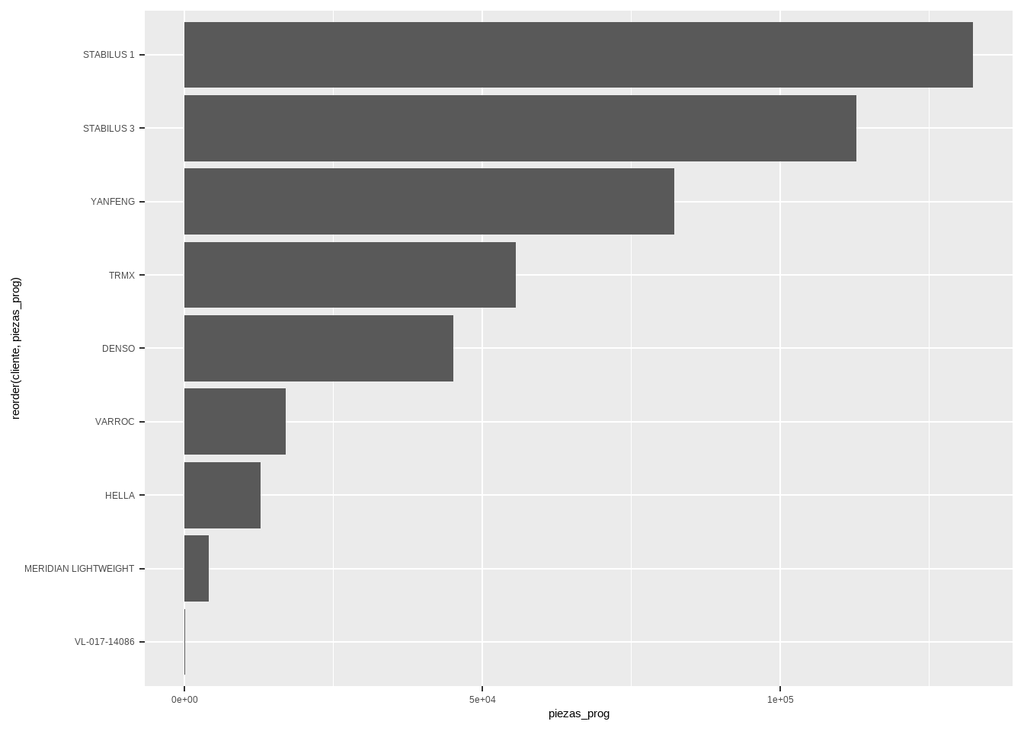

```r
produccion_alt1<-produccion_alt %>% select(cliente,piezas_prog) %>% group_by(cliente) %>% summarise(piezas_prog=sum(piezas_prog)) %>% arrange(desc(piezas_prog))
ggplot(produccion_alt1, aes(x=reorder(cliente,piezas_prog), y=piezas_prog)) +
  geom_bar(stat="identity")+
  coord_flip()
```

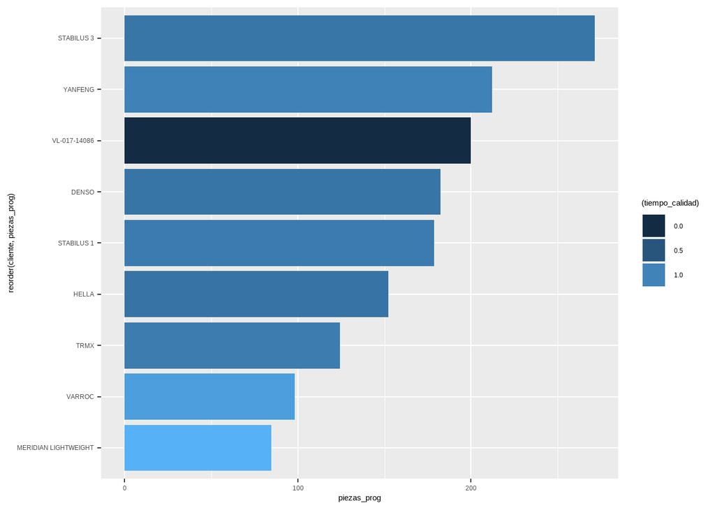

```r
produccion_alt2<-produccion_alt %>% select(cliente,piezas_prog,tiempo_calidad) %>% group_by(cliente) %>% summarise(across(everything(),mean,na.rm=TRUE)) %>% arrange(desc(piezas_prog))
ggplot(produccion_alt2, aes(x=reorder(cliente,piezas_prog), y=piezas_prog, fill=(tiempo_calidad))) +
  geom_bar(stat="identity")+
  coord_flip()+
  guides(fill=guide_legend(reverse=FALSE))
```

#### **Tabla 1: Resumen de Estadísticos Descriptivos de la Producción por Cliente**

```r
require(knitr)
require(survival)
produccion_alt2.1<-produccion_alt2 %>% filter(cliente %in% c('STABILUS 1','STABILUS 3','YANFENG','TRMX','DENSO'))
summary_tab1<-tableby(cliente ~ piezas_prog + tiempo_calidad, data=produccion_alt2.1, test=FALSE)
summary(summary_tab1, title= "Summary Statistics of Production by Client", width=45)
```

Summary Statistics of Production by Client

|  | DENSO (N=1) | STABILUS 1 (N=1) | STABILUS 3 (N=1) | TRMX (N=1) | YANFENG (N=1) | Total (N=5) |
| --- | --- | --- | --- | --- | --- | --- |
| **piezas_prog** |  |  |  |  |  |  |
| Mean (SD) | 182.298 (NA) | 178.703 (NA) | 271.370 (NA) | 124.321 (NA) | 212.095 (NA) | 193.758 (53.711) |
| Range | 182.298 - 182.298 | 178.703 - 178.703 | 271.370 - 271.370 | 124.321 - 124.321 | 212.095 - 212.095 | 124.321 - 271.370 |
| **tiempo_calidad** |  |  |  |  |  |  |
| Mean (SD) | 0.855 (NA) | 0.921 (NA) | 0.858 (NA) | 0.923 (NA) | 0.985 (NA) | 0.908 (0.054) |
| Range | 0.855 - 0.855 | 0.921 - 0.921 | 0.858 - 0.858 | 0.923 - 0.923 | 0.985 - 0.985 | 0.855 - 0.985 |

```r
produccion_alt3<-produccion_alt %>% select(cliente,piezas_prog,laminas_procesadas,tiempo_calidad) %>% group_by(cliente) %>%
  summarise(piezas_prog=sum(piezas_prog),laminas_procesadas=sum(laminas_procesadas),tiempo_calidad=sum(tiempo_calidad)) %>% arrange(desc(piezas_prog))
produccion_alt3<-produccion_alt3[-c(7,8,9),] # remove the last 3 rows
```

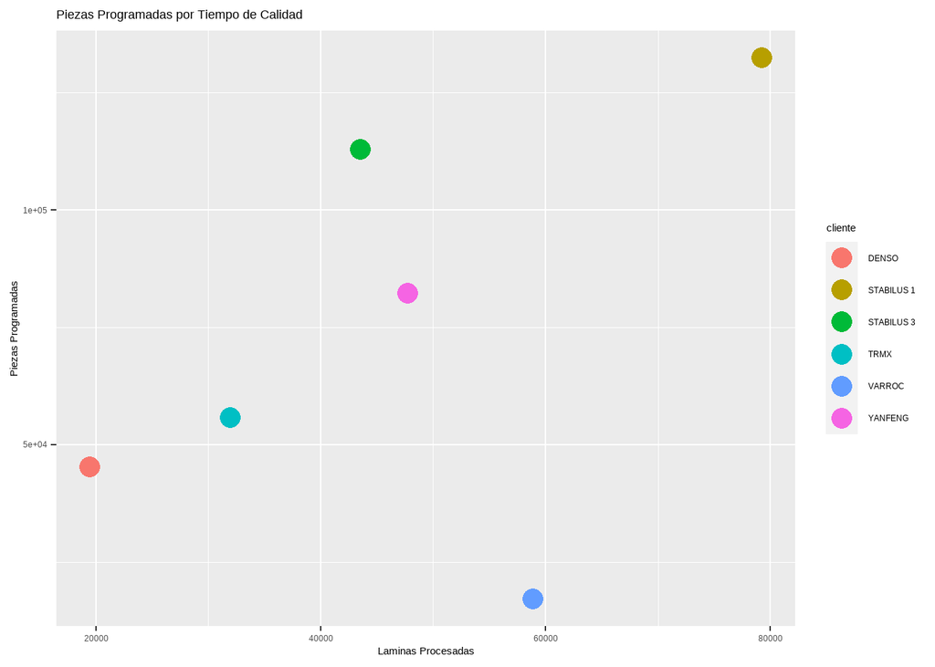

```r
ggplot(produccion_alt3, aes(x=laminas_procesadas, y=piezas_prog, color=cliente, shape=cliente)) +
  geom_point(shape=19,size=5)+
   labs(title="Piezas Programadas por Tiempo de Calidad",
       x="Laminas Procesadas", y = "Piezas Programadas")
```

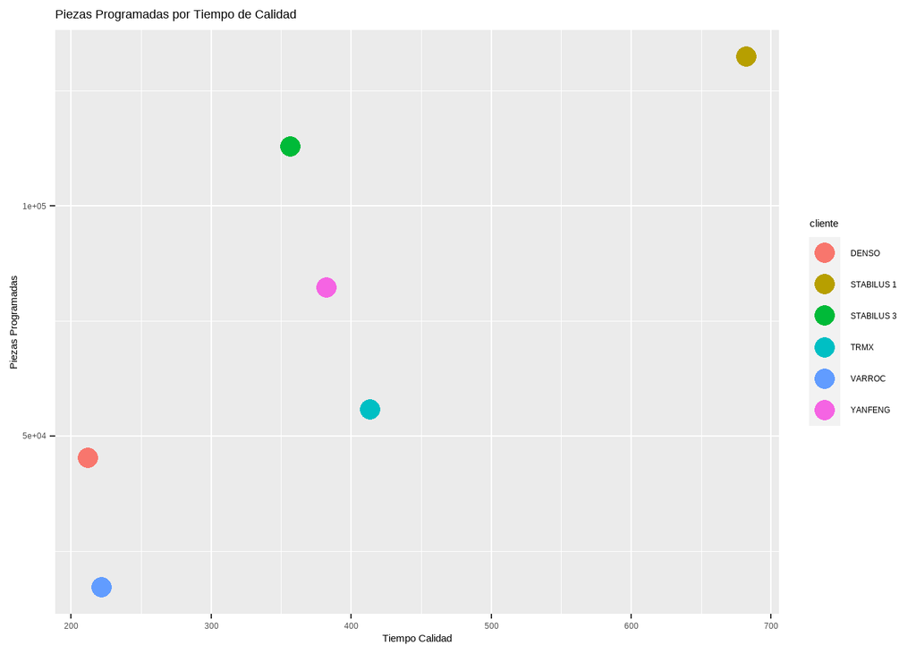

```r
ggplot(produccion_alt3, aes(x=tiempo_calidad, y=piezas_prog, color=cliente, shape=cliente)) +
  geom_point(shape=19,size=5)+
  labs(title="Piezas Programadas por Tiempo de Calidad",
       x="Tiempo Calidad", y = "Piezas Programadas")
```

#### which clients display the greatest dispersion on “piezas_prog”?

```r
produccion_alt4<-produccion_alt %>% select(cliente,piezas_prog) %>% arrange(desc(piezas_prog))
produccion_alt4<-produccion_alt4[-c(1099),] # remove client "VL-017-14086"
```

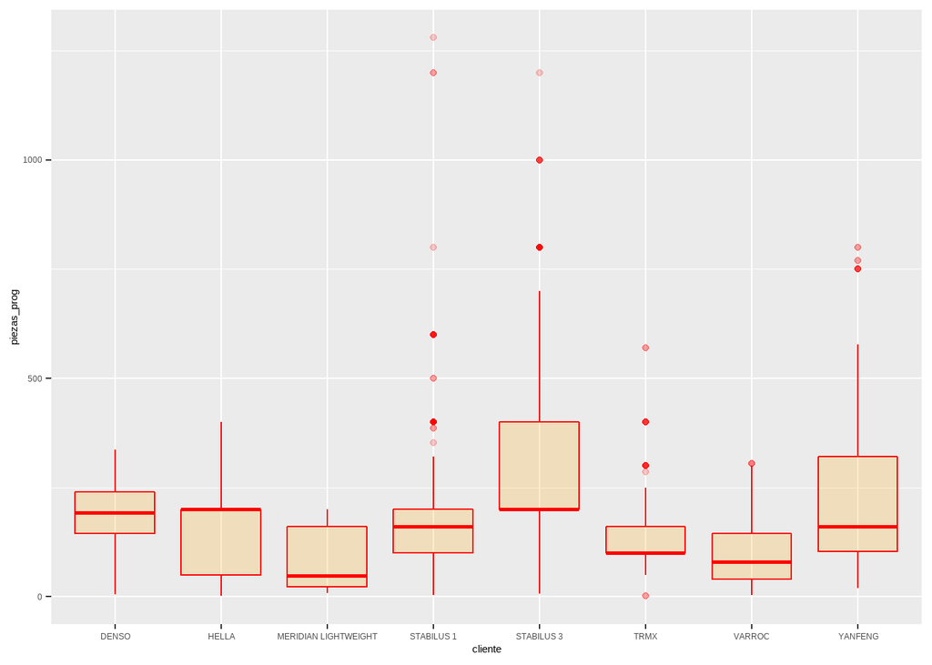

```r
ggplot(produccion_alt4, aes(x=cliente, y=piezas_prog)) +
  geom_boxplot(color="red", fill="orange", alpha=0.2)
```

```r
produccion_alt5<-produccion_alt %>% select(cliente,piezas_prog,tiempo_min) %>% group_by(cliente) %>%
  summarise(piezas_prog=sum(piezas_prog),tiempo_min=sum(tiempo_min)) %>% arrange(desc(piezas_prog))
produccion_alt5<-produccion_alt5[-c(7,8,9),] # remove the last 3 rows
```

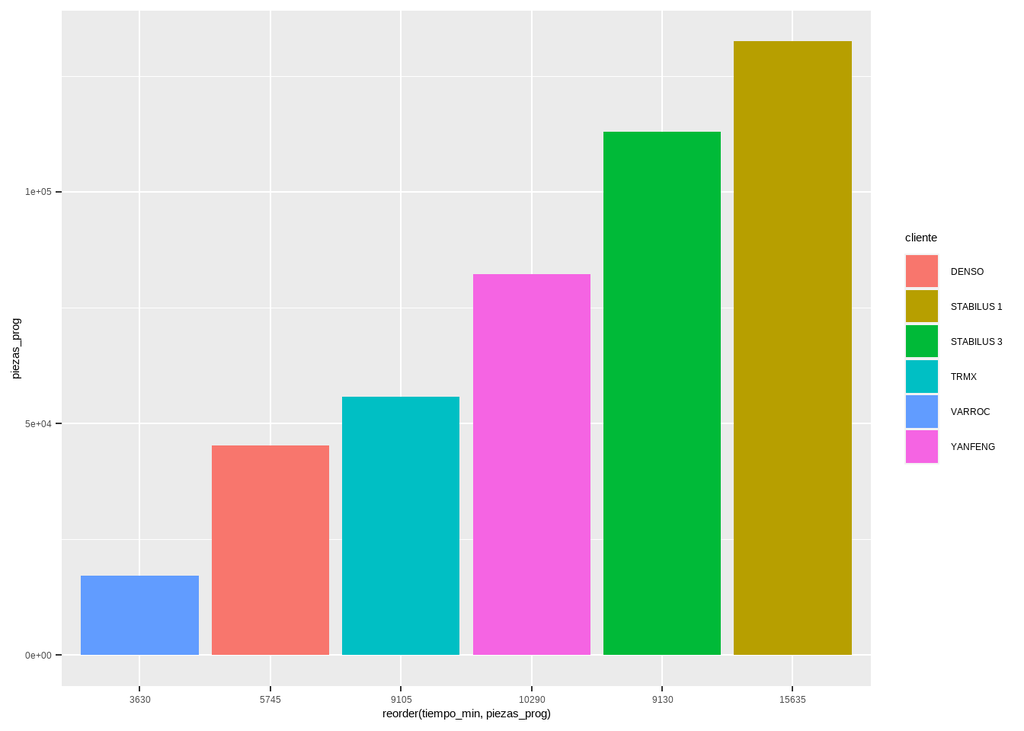

```r
ggplot(produccion_alt5,aes(x=reorder(tiempo_min,piezas_prog), y=piezas_prog,fill=cliente)) +
  geom_bar(stat="identity")
```

## **RECURSOS HUMANOS**

#### lets import the dataset

```r
rh<-read.csv("D:\\Tec21\\CD2001C\\FORM - Datos\\form_rh_datos.csv")
```

#### lets very the structure of the dataset

```r
str(rh)
```

```
## 'data.frame':    113 obs. of  27 variables:
##  $ No..De.Empleado      : int  NA 62 9 33 60 79 81 114 41 23 ...
##  $ APELLIDOS            : chr  "VERA VALDEZ" "CERDA HERNANDEZ" "MORENO SALINAS" "RODRIGUEZ MORENO" ...
##  $ NOMBRE               : chr  "JOSE MANUEL" "KEVIN ARTURO" "HUMBERTO" "NICOLAS DE JESUS" ...
##  $ FECHA.DE.NACIMIENTO  : chr  "12/23/1994" "10/23/2002" "11/3/1995" "1/11/1992" ...
##  $ HOY                  : chr  "9/23/2022" "9/23/2022" "9/23/2022" "9/23/2022" ...
##  $ GENERO               : chr  "MASCULINO" "MASCULINO" "MASCULINO" "MASCULINO" ...
##  $ RFC                  : chr  "VEVM9412238W8" "CEHK0210237V6" "MOSH9511033L4" "ROMN920411QUA" ...
##  $ FECHA.DE.ALTA        : chr  "8/18/2022" "2/18/2022" "1/11/2017" "11/3/2020" ...
##  $ Primer.mes           : int  44822 44640 42776 44168 44638 44743 44750 44762 44340 43866 ...
##  $ X4to.mes             : int  44913 44730 42866 44258 44728 44833 44840 44852 44430 43956 ...
##  $ BAJA                 : int  NA NA NA NA NA 3 3 NA NA NA ...
##  $ PUESTO               : chr  "MANTENIMIENTO" "AYUDANTE GENERAL" "AYUDANTE GENERAL" "AYUDANTE GENERAL" ...
##  $ DEPARTAMENTO         : chr  "" "Ay.flexo" "Cedis" "Cedis" ...
##  $ NO.SEGURO.SOCIAL     : chr  "35149402816" "27170227006" "56149534788" "" ...
##  $ SALARIO.DIARIO.IMSS  : num  181 181 177 177 181 ...
##  $ FACTOR.CRED.INFONAVIT: chr  "N/A" "N/A" "" "" ...
##  $ NO..CREDITO.INFONAVIT: chr  "N/A" "N/A" "" "" ...
##  $ LUGAR.DE.NACIMIENTO  : chr  "EBANO, SAN LUIS POTOSI" "MONTERREY, NUEVO LEON" "" "" ...
##  $ CURP                 : chr  "VEVM941223HSPRLN07" "CEHK021023HNLRRVA8" "MOSH951103HVZRLM03" "ROMN920411HCLDRC00" ...
##  $ CALLE                : chr  "MIER Y NORIEGA" "PORTAL GALICIA" "OCEANIA" "TASAJILLO" ...
##  $ NUMERO.INTERNO       : chr  "106B" "219" "" "220" ...
##  $ COLONIA              : chr  "MIRADOR DE SAN ANTONIO" "PORTAL DEL VALLE" "FRACC. OCEANIA BOULEVARES" "EL CACTUS" ...
##  $ MUNICIPIO            : chr  "JUAREZ" "APODACA" "SALTILLO" "RAMOS ARIZPE" ...
##  $ ESTADO               : chr  "NUEVO LEON" "NUEVO LEON" "COAHUILA" "COAHUILA" ...
##  $ CODIGO.POSTAL        : int  67255 66643 25290 25902 66646 67114 66646 66649 66643 66647 ...
##  $ ESTADO.CIVIL         : chr  "MATRIMONIO" "SOLTERIA" "MATRIMONIO" "UNION LIBRE" ...
##  $ TARJETA.CUENTA       : chr  "SANTANDER" "BANORTE" "BANORTE" "BANORTE" ...
```

#### select columns / variables

```r
rh_alt<-rh %>% select(-one_of('No..De.Empleado','APELLIDOS','NOMBRE','RFC','FECHA.DE.ALTA','Primer.mes','X4to.mes','BAJA','NO.SEGURO.SOCIAL','FACTOR.CRED.INFONAVIT','NO..CREDITO.INFONAVIT','LUGAR.DE.NACIMIENTO',
                          'CURP','CALLE','NUMERO.INTERNO','COLONIA','CODIGO.POSTAL','TARJETA.CUENTA'))
```

#### lets rename the selected columns / variables

```r
colnames(rh_alt)<-c('fecha_nacimiento','fecha_actual','genero','puesto','depto','salario_diario','mpio','estado','estado_civil')
```

#### lets convert “fecha_nacimiento” to date format

```r
rh_alt$fecha_nacimiento<-as.Date(rh_alt$fecha_nacimiento,format="%m/%d/%Y")
rh_alt$fecha_actual<-as.Date(rh_alt$fecha_actual,format="%m/%d/%Y")
```

#### lets calculate the variable “age” in years so we can realize additional characteristics of “colaboradores”

```r
library(lubridate)
edad<-trunc((rh_alt$fecha_nacimiento %--% rh_alt$fecha_actual) / years(1)) # %--% creates a time interval based on as.date() format
rh_alt$edad<-edad
```

#### lets convert character variables to factor so we can display descriptive statistics

```r
rh_alt$genero<-as.factor(rh_alt$genero)
rh_alt$puesto<-as.factor(rh_alt$puesto)
rh_alt$depto<-as.factor(rh_alt$depto)
rh_alt$mpio<-as.factor(rh_alt$mpio)
rh_alt$estado<-as.factor(rh_alt$estado)
rh_alt$estado_civil<-as.factor(rh_alt$estado_civil)
```

#### lets verify the structure of our rh_alt dataset

```r
str(rh_alt)
```

```
## 'data.frame':    113 obs. of  10 variables:
##  $ fecha_nacimiento: Date, format: "1994-12-23" "2002-10-23" ...
##  $ fecha_actual    : Date, format: "2022-09-23" "2022-09-23" ...
##  $ genero          : Factor w/ 2 levels "FEMENINO","MASCULINO": 2 2 2 2 1 1 1 2 1 1 ...
##  $ puesto          : Factor w/ 19 levels "AYUDANTE GENERAL",..: 12 1 1 1 1 1 1 1 1 1 ...
##  $ depto           : Factor w/ 22 levels "","Ay.flexo",..: 1 2 4 4 6 6 6 7 9 17 ...
##  $ salario_diario  : num  181 181 177 177 181 ...
##  $ mpio            : Factor w/ 9 levels "CA\xd1ADA BLANCA",..: 4 2 8 7 2 3 2 2 2 2 ...
##  $ estado          : Factor w/ 2 levels "COAHUILA","NUEVO LEON": 2 2 1 1 2 2 2 2 2 2 ...
##  $ estado_civil    : Factor w/ 4 levels "DIVORCIO","MATRIMONIO",..: 2 3 2 4 3 3 4 2 2 2 ...
##  $ edad            : num  27 19 26 30 45 56 35 32 50 54 ...
```

```r
summary(rh_alt)
```

```
##  fecha_nacimiento      fecha_actual              genero                puesto
##  Min.   :1949-11-21   Min.   :2022-09-23   FEMENINO :61   AYUDANTE GENERAL:67
##  1st Qu.:1977-04-20   1st Qu.:2022-09-23   MASCULINO:52   COSTURERA       :10
##  Median :1989-01-22   Median :2022-09-23                  CHOFER          : 5
##  Mean   :1986-09-01   Mean   :2022-09-23                  SOLDADOR        : 5
##  3rd Qu.:1997-01-03   3rd Qu.:2022-09-23                  RESIDENTE       : 4
##  Max.   :2022-02-23   Max.   :2022-09-23                  SUPERVISOR      : 4
##  NA's   :1                                                (Other)         :18
##                    depto    salario_diario             mpio           estado
##                       :40   Min.   :1.440e+02   APODACA  :72   COAHUILA  :  9
##  Produccion Retorn    :10   1st Qu.:1.770e+02   JUAREZ   :10   NUEVO LEON:104
##  Costura              : 7   Median :1.810e+02   PESQUERIA: 9
##  Produccion Carton MDL: 7   Mean   :1.346e+07   GUADALUPE: 6
##  Stabilus             : 7   3rd Qu.:1.810e+02   SALTILLO : 5
##  Cedis                : 6   Max.   :1.517e+09   MONTERREY: 4
##  (Other)              :36                       (Other)  : 7
##       estado_civil      edad
##  DIVORCIO   : 3    Min.   : 0.00
##  MATRIMONIO :44    1st Qu.:25.00
##  SOLTERIA   :46    Median :33.50
##  UNION LIBRE:20    Mean   :35.55
##                    3rd Qu.:45.00
##                    Max.   :72.00
##                    NA's   :1
```

#### lets verify the presence of missing values

```r
rh_alt<-rh_alt[-c(53),] # remove row # 53 because it shows a missing value.
summary(rh_alt) # no missing values
```

```
##  fecha_nacimiento      fecha_actual              genero                puesto
##  Min.   :1949-11-21   Min.   :2022-09-23   FEMENINO :61   AYUDANTE GENERAL:66
##  1st Qu.:1977-04-20   1st Qu.:2022-09-23   MASCULINO:51   COSTURERA       :10
##  Median :1989-01-22   Median :2022-09-23                  CHOFER          : 5
##  Mean   :1986-09-01   Mean   :2022-09-23                  SOLDADOR        : 5
##  3rd Qu.:1997-01-03   3rd Qu.:2022-09-23                  RESIDENTE       : 4
##  Max.   :2022-02-23   Max.   :2022-09-23                  SUPERVISOR      : 4
##                                                           (Other)         :18
##                    depto    salario_diario             mpio           estado
##                       :39   Min.   :1.440e+02   APODACA  :71   COAHUILA  :  9
##  Produccion Retorn    :10   1st Qu.:1.770e+02   JUAREZ   :10   NUEVO LEON:103
##  Costura              : 7   Median :1.810e+02   PESQUERIA: 9
##  Produccion Carton MDL: 7   Mean   :1.358e+07   GUADALUPE: 6
##  Stabilus             : 7   3rd Qu.:1.810e+02   SALTILLO : 5
##  Cedis                : 6   Max.   :1.517e+09   MONTERREY: 4
##  (Other)              :36                       (Other)  : 7
##       estado_civil      edad
##  DIVORCIO   : 3    Min.   : 0.00
##  MATRIMONIO :44    1st Qu.:25.00
##  SOLTERIA   :46    Median :33.50
##  UNION LIBRE:19    Mean   :35.55
##                    3rd Qu.:45.00
##                    Max.   :72.00
##
```

#### lets display data visualization plots so we can identify relevant insights from our rh_alt dataset

```r
tapply(rh_alt$salario_diario,
       list(rh_alt$genero,rh_alt$estado_civil), mean)
```

```
##           DIVORCIO   MATRIMONIO    SOLTERIA UNION LIBRE
## FEMENINO    180.68 1.842905e+02 176718.0296    180.9669
## MASCULINO   176.72 6.594489e+07    176.1038    180.0200
```

#### replace the “outlier” of salario_diario with the median

```r
rh_alt$salario_diario<-replace(rh_alt$salario_diario,rh_alt$salario_diario>1000000,181)
```

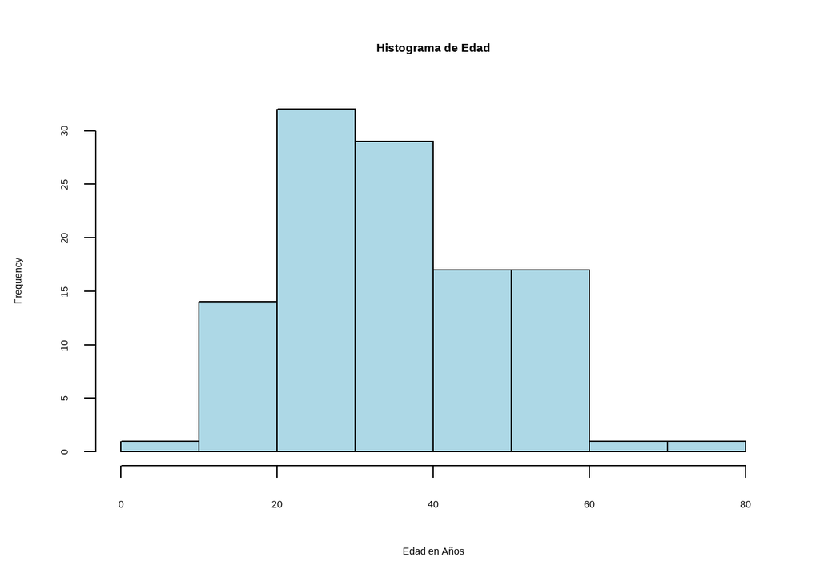

```r
hist(rh_alt$edad, freq=TRUE, col='light blue', main="Histograma de Edad",xlab="Edad en Años")
```

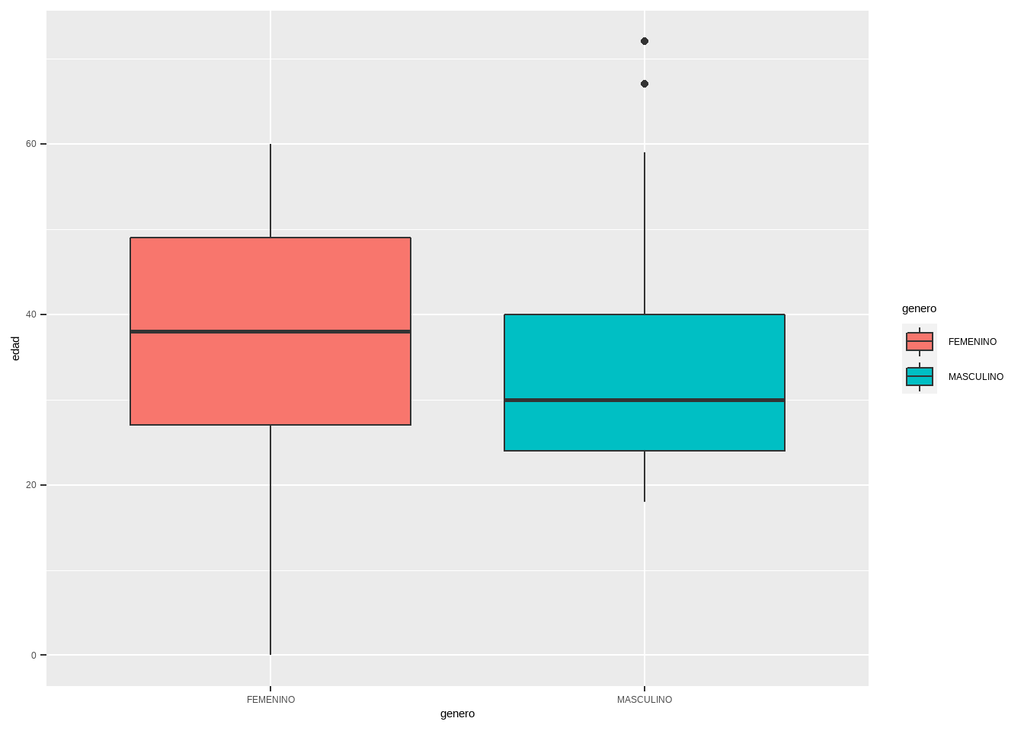

```r
ggplot(rh_alt, aes(x=genero, y=edad, fill=genero)) +
  geom_boxplot()
```

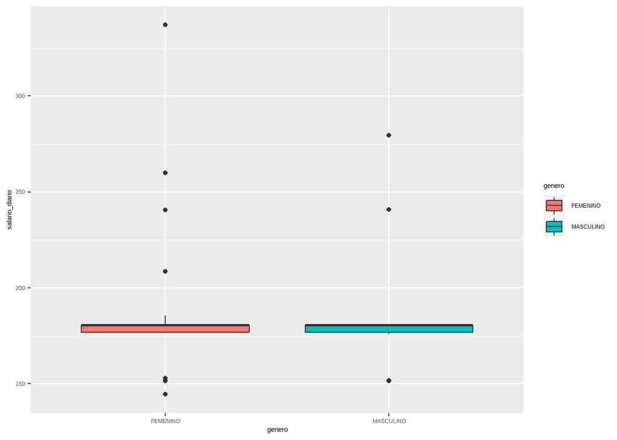

```r
ggplot(rh_alt, aes(x=genero, y=salario_diario, fill=genero)) +
  geom_boxplot()
```

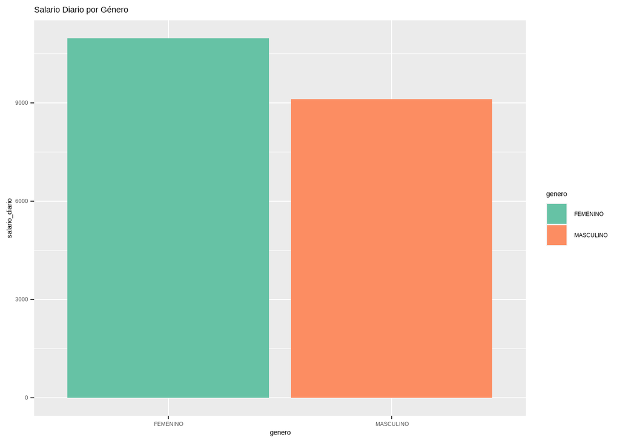

```r
ggplot(rh_alt, aes(genero,salario_diario,fill=genero)) +
  geom_bar(stat = "identity") +
  scale_fill_brewer(palette = "Set2") + ggtitle("Salario Diario por Género")
```

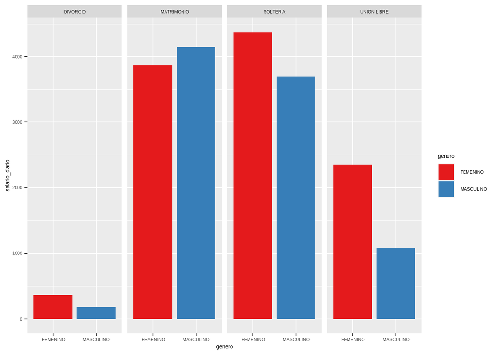

```r
ggplot(rh_alt, aes(x=genero, y=salario_diario, fill=genero)) +
  geom_bar(stat="identity") +
  facet_grid(~estado_civil) + scale_fill_brewer(palette = "Set1")
```

#### **Tabla 2: Salario Diario por Estado Civil y Género**

```r
require(knitr)
require(survival)
summary_tab2<-tableby(genero ~ salario_diario + edad + estado_civil, data=rh_alt,test=FALSE)
summary(summary_tab2, title="Daily Wage and Marital Status by Gender")
```

Daily Wage and Marital Status by Gender

|  | FEMENINO (N=61) | MASCULINO (N=51) | Total (N=112) |
| --- | --- | --- | --- |
| **salario_diario** |  |  |  |
| Mean (SD) | 179.652 (27.895) | 178.479 (19.661) | 179.118 (24.394) |
| Range | 144.450 - 337.050 | 151.610 - 279.610 | 144.450 - 337.050 |
| **edad** |  |  |  |
| Mean (SD) | 37.328 (12.970) | 33.431 (13.466) | 35.554 (13.282) |
| Range | 0.000 - 60.000 | 18.000 - 72.000 | 0.000 - 72.000 |
| **estado_civil** |  |  |  |
| DIVORCIO | 2 (3.3%) | 1 (2.0%) | 3 (2.7%) |
| MATRIMONIO | 21 (34.4%) | 23 (45.1%) | 44 (39.3%) |
| SOLTERIA | 25 (41.0%) | 21 (41.2%) | 46 (41.1%) |
| UNION LIBRE | 13 (21.3%) | 6 (11.8%) | 19 (17.0%) |

## **DISTRIBUCIÓN**

#### lets import the dataset

```r
delivery_performance<-read.csv("D:\\Tec21\\CD2001C\\FORM - Datos\\form_delivery_performance.csv")
str(delivery_performance)
```

```
## 'data.frame':    52 obs. of  3 variables:
##  $ fecha            : chr  "7/31/2021" "7/31/2021" "7/31/2021" "7/31/2021" ...
##  $ cliente          : chr  "Printel" "Mahle" "Magna" "Varroc" ...
##  $ delay_performance: num  4.9 15.7 0 0 27.7 ...
```

#### lets convert our dataset to data.frame format and set the date format

```r
delivery_performance<-as.data.frame(delivery_performance)
delivery_performance$fecha<-as.Date(delivery_performance$fecha,format="%m/%d/%Y")
delivery_performance$cliente<-as.factor(delivery_performance$cliente)
```

#### lets verify the dataset’s structure and summary of descriptive statistics

```r
summary(delivery_performance)
```

```
##      fecha               cliente   delay_performance
##  Min.   :2021-07-31   Magna  :13   Min.   : 0.00
##  1st Qu.:2021-10-31   Mahle  :13   1st Qu.: 0.00
##  Median :2022-01-31   Printel:13   Median : 0.00
##  Mean   :2022-01-29   Varroc :13   Mean   :16.14
##  3rd Qu.:2022-04-30                3rd Qu.:29.38
##  Max.   :2022-07-31                Max.   :71.25
```

#### lets plot delay performance by client

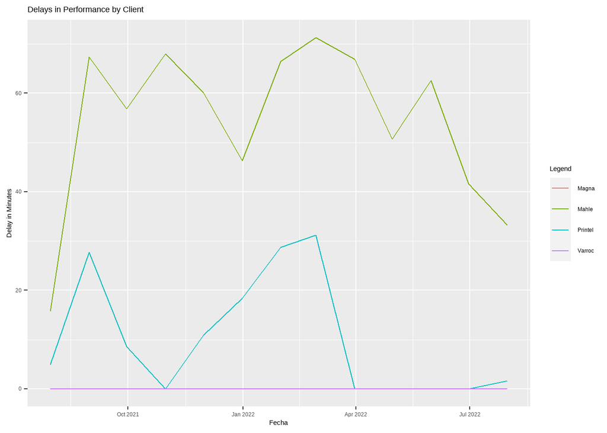

```r
ggplot(delivery_performance,aes(x=fecha, y=delay_performance,color=cliente))+
  geom_line()+
  labs(x="Fecha",y="Delay in Minutes", color="Legend")+
  ggtitle("Delays in Performance by Client")
```

#### lets remove two clients displaying 0’s values of delay performance

```r
delivery_performance<-delivery_performance[delivery_performance$cliente!="Magna",]
delivery_performance<-delivery_performance[delivery_performance$cliente!="Varroc",]
```

#### lets get the mean value of delay performance so we can display it in the next plot

```r
summary(delivery_performance$delay_performance)
```

```
##    Min. 1st Qu.  Median    Mean 3rd Qu.    Max.
##   0.000   5.825  29.990  32.270  59.280  71.250
```

#### lets plot again the 2 clients characterized by the longest delay

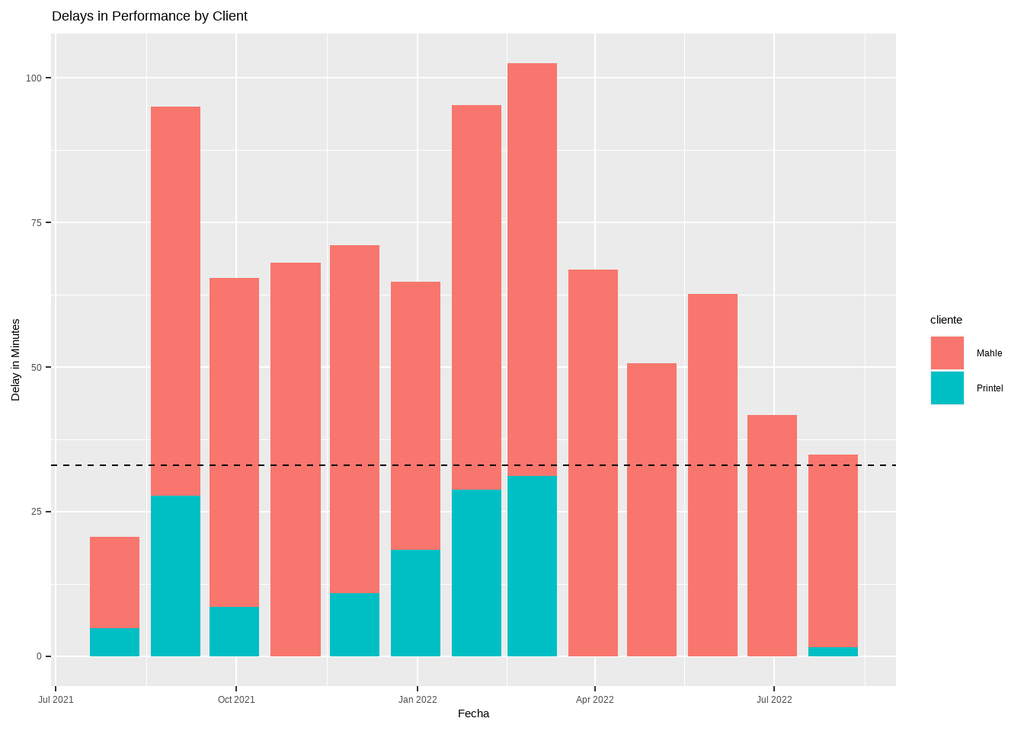

```r
ggplot(delivery_performance,aes(x=fecha, y=delay_performance,fill=cliente))+
  geom_bar(stat="identity")+
  geom_hline(yintercept=33,linetype="dashed",color="black")+
  labs(x="Fecha",y="Delay in Minutes", color="Legend")+
  ggtitle("Delays in Performance by Client")
```

#### importing and preparing delivery_plan dataset

```r
del_plan_alt<-read.csv("D:\\Tec21\\CD2001C\\delivery_plan.csv")
colnames(del_plan_alt)<-c('cliente','Jan','Feb','Mar','Apr','May','June','July','Aug','Sept','Oct','Nov','Dec')
del_plan_alt1<-del_plan_alt %>% group_by(cliente) %>% summarise(Jan=sum(Jan),Feb=(sum(Feb)),Mar=sum(Mar),Apr=sum(Apr),May=sum(May),June=sum(June),
                                                                July=sum(July),Aug=sum(Aug),Sept=sum(Sept),Oct=sum(Oct),Nov=sum(Nov),Dec=sum(Dec))
```

#### lets drop clients showing 0 values

```r
del_plan_alt1<-del_plan_alt1[-c(1,2,8,10,19),]
del_plan_alt1<-as.data.frame(del_plan_alt1)
```

#### lets convert to our delivery_plan dataset to format that we can display it in a heat map

#### it organizes the data values in a long data frame format

```r
del_plan_alt2<-melt(del_plan_alt1,id.vars='cliente',variable.name='series')
summary(del_plan_alt2)
```

```
##    cliente              series       value
##  Length:168         Jan    :14   Min.   :    0.0
##  Class :character   Feb    :14   1st Qu.:    0.0
##  Mode  :character   Mar    :14   Median :   40.0
##                     Apr    :14   Mean   : 2378.8
##                     May    :14   3rd Qu.:  638.8
##                     June   :14   Max.   :48132.0
##                     (Other):84
```

#### lets visualize a heatmap to detect important delivery dates by client

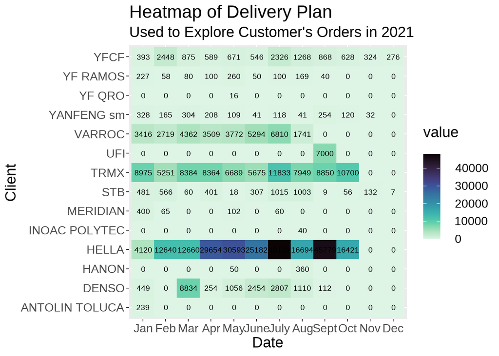

```r
del_plan_alt2 %>%
  ggplot(aes(series,cliente)) +
  geom_tile(aes(fill=value))+
  geom_text(aes(label=value),size=5.5)+
  scale_fill_viridis(discrete=FALSE,direction=-1,option="G")+
  labs(title="Heatmap of Delivery Plan",
       subtitle="Used to Explore Customer's Orders in 2021",
       x="Date",
       y="Client")+
  theme(text=element_text(size=30))
```